# Analyzing urban greeness equity

Roshan Sharma

5 September 2020

**1. Introduction**

Green spaces and infrastructures such as street trees,parks and gardens,and green belts provide recreation and along with important health and other well-being benefits. Socioeconomic disadvantages, where certain areas have more access to resources, is a common phenomenon in urban landscapes. In such circumstances, inequitable access to natural assets may further worsen the well-being of already marginalized residents. A double whammy effect. We investigate whether such patterns are evident in the suburbs of Melbourne, Australia.

**2. Methods**

> **2.1 Datasets**

Green spaces and infrastructures such as street trees,parks and gardens,and green belts provide recreation and along with important health and other well-being benefits. Socioeconomic disadvantages, where certain areas have more access to resources, is a common phenomenon in urban landscapes. In such circumstances, inequitable access to natural assets may further worsen the well-being of already marginalized residents. A double whammy effect. We investigate whether such patterns are evident in the suburbs of Melbourne, Australia.

> **Australian Bureau of Statistics dataset**

This dataset indicates the collective socio-economic characteristics of the people living in an area.

*Dataset is available here (https://www.abs.gov.au/AUSSTATS/abs@.nsf/DetailsPage/2033.0.55.0012016?OpenDocument)

*Technical report is available here (https://www.ausstats.abs.gov.au/ausstats/subscriber.nsf/0/756EE3DBEFA869EFCA258259000BA746/$File/SEIFA%202016%20Technical%20Paper.pdf).

> **VIC Suburb/Locality Boundary - PSMA Administrative Boundaries**

This is the spatial dataset that shows suburbs and is derived from the cadastre data from each Australian state.

*Dataset is available here (https://data.gov.au/dataset/ds-dga-af33dd8c-0534-4e18-9245-fc64440f742e/details).

> **NDVI**

I used NDVI as an indicator of green infrastructure. NDVI captures signals from all vegetation types. I derived median NDVI value from Landsat 8 for the year 2020 from Google Earth Engine. This is also an open-source data, I will put the data in the shared repository.

> **2.2 R packages to use**

```r
##Spatial analysis
library(sf) # Loading sf objects (polygons)
library(raster) #Loading raster
library(spatialEco) #Fast intersection/clipping
library(prioritizr) #Fast extraction of raster values
library(tmap) #For mapping

##Data cleaning
library(tidyverse)
library(stringr)
library(ggpmisc) ##For R2 in scatterplot

##Colors for visualization
library(RColorBrewer)
library(viridis)
```

> **2.3 Load and clean datasets**

We need to join the ABS socio-economic data to the suburb polygons. This is a bit tricky treat as differences on the suburb names of joining columns can cause issue. Also there could be changes in suburb names, along with frequent addition or merging of suburbs. Although we have tried to join the data as concisely as possible, there could be some margin of errors. Further, we were not able to get/join data for some suburbs.

```r
######## SUBURB POLYGONS #########

## Load Suburb Polygons
vic.suburbs <- read_sf("./vic_locality_polygon_shp-gda2020/VIC_LOCALITY_POLYGON_shp GDA2020/VIC_LOCALITY_POLYGON_shp.shp")

## Load Melbourne metropolitan boundary
melb <- st_read("./Administrative/Metropolitan region_region.shp")

##Since we are doing some clipping. It is safe side to always make the CRS same. Here we have changed it to WGS84
st_crs(vic.suburbs) <- 4326
st_crs(melb) <- 4326

##Clip the suburbs to metro Melbourne ##Don't clip as it will create small fragments of suburbs
#suburbs <- st_intersection(vic.suburbs,melb)

##Use spatialEco where the predicate argument controls the type of intersection (intersect", "contains", "covers", "touches", "proximity").

suburbs <- spatial.select(melb,vic.suburbs,predicate="intersect")

##Select only the columns required and also trim_whitespace as we need to join later
suburbs <- suburbs %>%
                select(VIC_LOCA_2)%>%
                    mutate(across(where(is.character),str_trim)) %>% ##Trim whitespace
                      mutate(area=as.numeric(st_area(suburbs)*1e-6)) ##Gives results in sq.m change to sqkm

##Dropping the geometry is convenient to check your data in viewer
check <- st_drop_geometry(suburbs)

##Rename for convenience
colnames(suburbs) <- c("sub","geometry","area")

####### SOCIO-ECONOMIC DATA ########

##Read the excel file, the data is in sheet 2
socio <- readxl::read_xls("./2033055001 - ssc indexes_socio-economic.xls",
                          sheet=2)

##Select only the required columns and filter NA rows
socio <- socio %>%
          select(2,3,11) %>%
            filter(!is.na(socio$...2))

socio <- socio[-1,]

colnames(socio) <- c("sub","index","pop2016")

## There are some issues with the suburb names in this data. As we need to join this with our polygons, we need to clean it.

socio <- socio %>%
          mutate(sub=str_to_upper(sub),
                  sub=str_replace(sub,"\\(VIC.*\\)",""), ##Remove VIC string for matching/join
                    index=as.numeric(index),
                      pop2016=as.numeric(pop2016),  ## Change to numeric
                       across(where(is.character),str_trim)) ##Remove white lines (spaces in front and end)

####LOAD THE NDVI DATA

ndvidata <- raster("ndvi-melbourne-2020-medianNEW.tif")

##Join the socio data first
data.final <- left_join(suburbs,socio)

## Add NDVI data
data.final <- data.final %>%
                mutate(ndvi=as.numeric(fast_extract(ndvidata,suburbs,fun="mean")))

##Calculate population density
data.final <- data.final %>%
               mutate(density=as.numeric(pop2016/area))

##Strap geometry for investigation purpose only
seedata <- st_drop_geometry(data.final)
```

**3. Results**

> **3.1 Exploratory analysis**

We plot the maps and visually inspect the data

**Relative Socio-Economic Disadvantage Index and NDVI distribution**

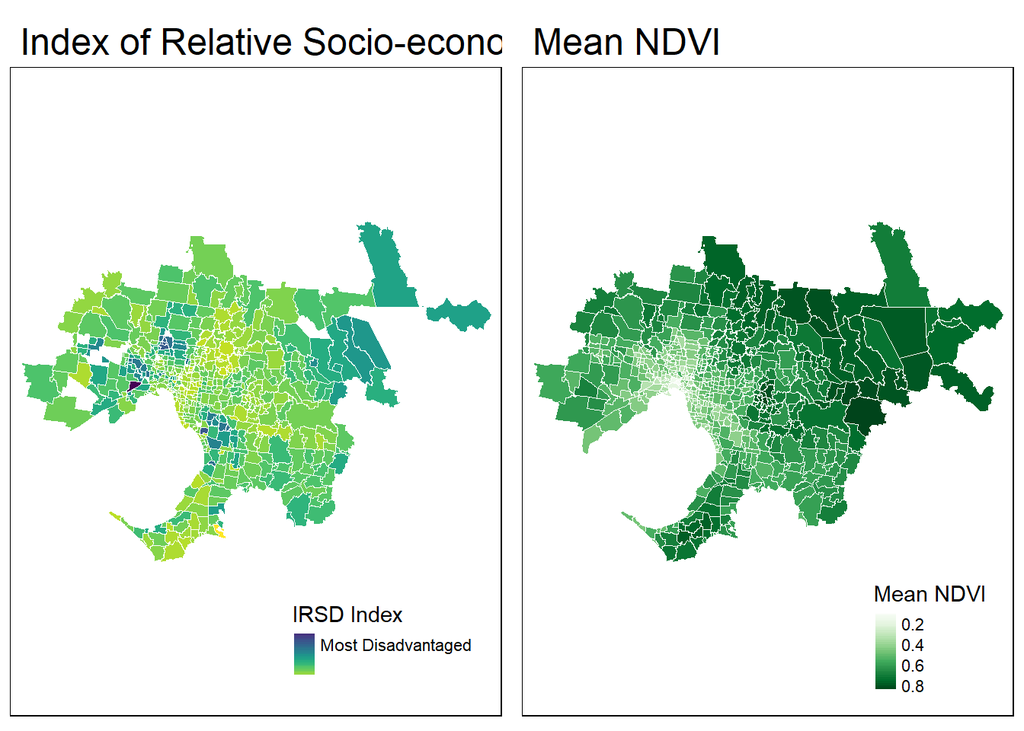

```r
a <- tm_shape(data.final)+

 tm_fill("index",
  title="IRSD Index",
  labels=c("Most Disadvantaged","",""),
  style="cont",
  colorNA="white", ##Change missing value to white
  textNA="", ##Don't show missing in the legend
  palette="viridis")+

 tm_borders(col="white",lwd=0.2) +

 tm_layout(main.title="Index of Relative Socio-economic Disadvantage (IRSD)",
           title.position=c("left","top"))
           #frame = FALSE)

##Define a color palette
greens <- colorRampPalette(brewer.pal(9,'Greens'))(100)

b <- tm_shape(data.final)+

 tm_fill("ndvi",
  title="Mean NDVI",
  style="cont",
  colorNA="white", ##Change missing value to white
  textNA="", ##Don't show missing in the legend
  palette=greens)+

 tm_borders(col="white",lwd=0.2) +

 tm_layout(main.title="Mean NDVI",
           title.position=c("left","top"))
           #frame = FALSE)

##Arrange both these plots

tmap_arrange(a,b,nrow=1,ncol=2)
```

**Population Count and Density**

Also let’s plot the pop data, to explore if this could be used anyway for the analysis.

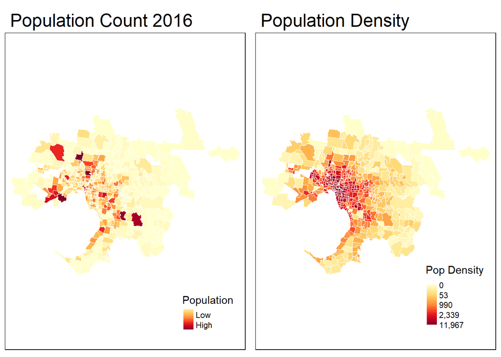

```r
c <- tm_shape(data.final)+

 tm_fill("pop2016",
  title="Population",
  labels=c("Low","High"),
  style="cont",
  colorNA="white", ##Change missing value to white
  textNA="", ##Don't show missing in the legend
  palette = "YlOrRd")+

 tm_borders(col="white",lwd=0.2) +

 tm_layout(main.title="Population Count 2016",
           title.position=c("left","top"))
           #frame = FALSE)

d <- tm_shape(data.final)+
       tm_fill("density",
         title="Pop Density",
         style = "order",  ## This style suited to visualize skewed distribution
         colorNA="white", ##Change missing value to white
         textNA="", ##Don't show missing in the legend
         palette = "YlOrRd")+

     tm_borders(col="white",lwd=0.2) +

     tm_layout(main.title="Population Density",
           title.position=c("left","top"))

tmap_arrange(c,d,nrow=1,ncol=2)
```

> **3.2 Some statistical analysis**

Let’s make a scatter plot and fit a line

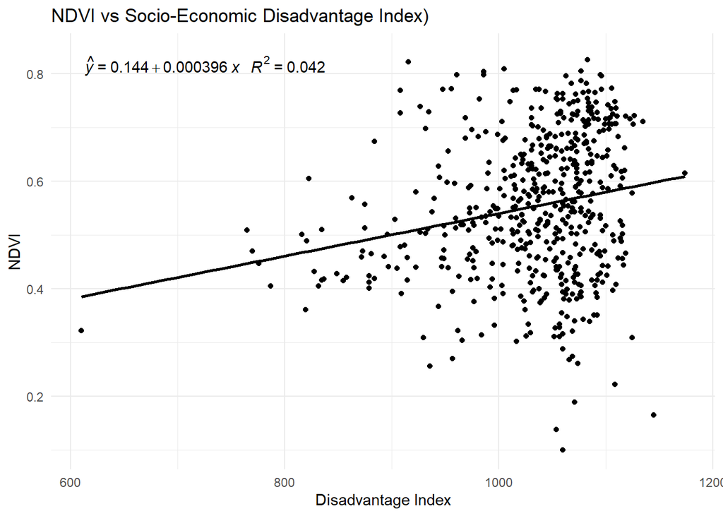

```r
# Make a ggplot object
a <- ggplot(data.final, aes(x = index, y = ndvi))

# Add points and regression line
a + geom_point() +
    geom_smooth(method = lm,se=F, color="black",formula = y~x) +
    stat_poly_eq(formula = y~x,
                eq.with.lhs = "italic(hat(y))~`=`~",
                aes(label = paste(..eq.label.., ..rr.label.., sep = "~~~")),
                parse = TRUE)+
    theme_minimal()+
    labs(title="NDVI vs Socio-Economic Disadvantage Index)",
       x ="Disadvantage Index",
       y ="NDVI" )
```

Oh the outlier - remove it

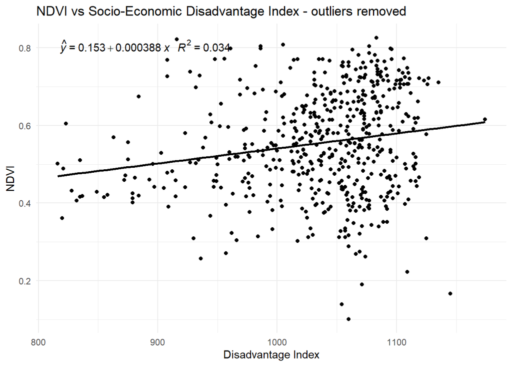

```r
outlier.removed <- data.final %>%
                   filter(index>800)

a <- ggplot(outlier.removed, aes(x = index, y = ndvi))

# Add points and regression line
my.formula <- y ~ x

a + geom_point() +
    geom_smooth(method = lm, se=F, color="black",formula = y~x) +
    stat_poly_eq(formula = y~x,
                eq.with.lhs = "italic(hat(y))~`=`~",
                aes(label = paste(..eq.label.., ..rr.label.., sep = "~~~")),
                parse = TRUE)+
    theme_minimal()+
    labs(title="NDVI vs Socio-Economic Disadvantage Index - outliers removed",
       x ="Disadvantage Index",
       y ="NDVI" )
```

Conclusion is that there is no pattern.

However, what we can see (with the dots on the lower left corner) is that there are many disadvantaged suburbs that have low NDVI values. What are the implications for this??? Perhaps these suburbs can be a target for intervention ????

Let’s make another scatter plot for NDVI vs Population

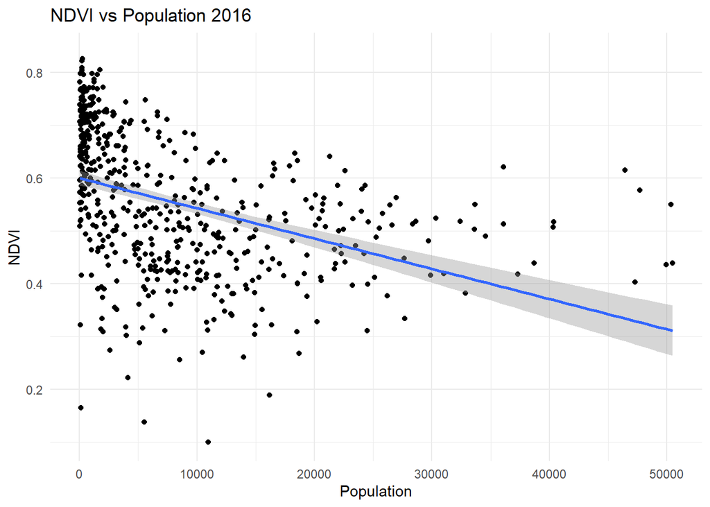

```r
# Make a ggplot object
b <- ggplot(data.final, aes(x = pop2016, y = ndvi))

# Add points and regression line
b + geom_point()+
    geom_smooth(method = lm)+
    theme_minimal()+
    labs(title="NDVI vs Population 2016",
       x ="Population",
       y ="NDVI" )
```

This is already quite evident, areas of higher population have lower NDVIs.

NDVI vs Population density

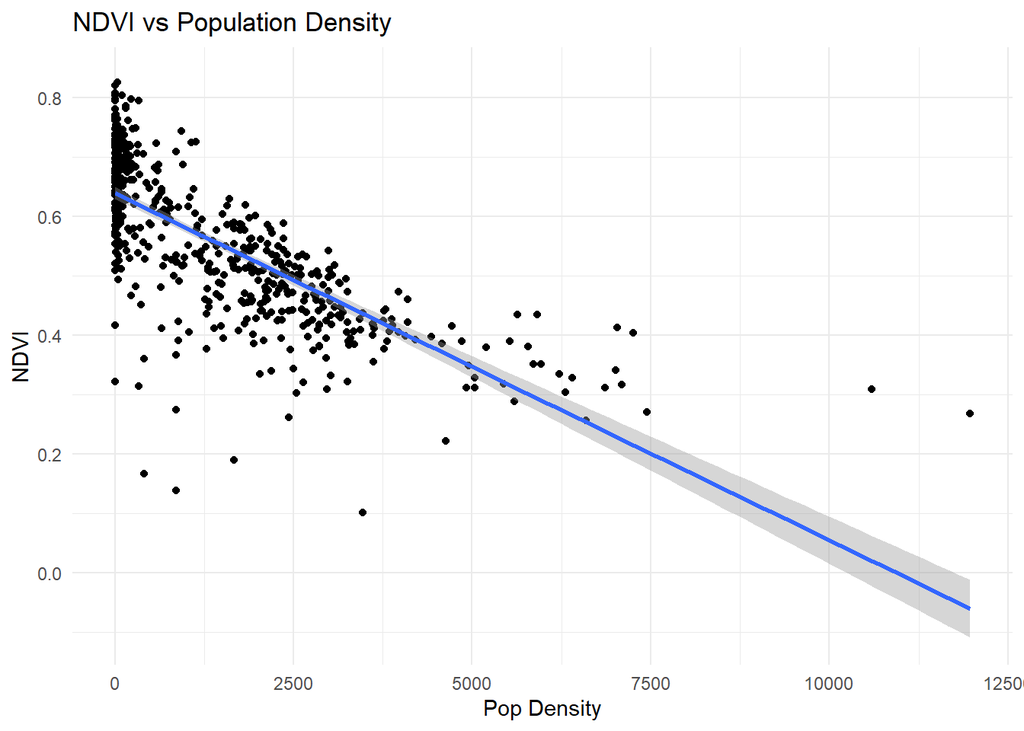

```r
options(scipen=1000000)

# Make a ggplot object
b <- ggplot(data.final, aes(x = density, y = ndvi))

# Add points and regression line
b + geom_point()+
    geom_smooth(method = lm)+
    theme_minimal()+
    labs(title="NDVI vs Population Density",
       x ="Pop Density",
       y ="NDVI" )
```

Why don’t we see the per-capita NDVI and then see if there is any associated pattern with socio-economic disadvantage?